# MovieLens Project Questions

### Project - MovieLens Data Analysis

The GroupLens Research Project is a research group in the Department of Computer Science and Engineering at the University of Minnesota. The data is widely used for collaborative filtering and other filtering solutions. However, we will be using this data to act as a means to demonstrate our skill in using Python to “play” with data.

#### Domain

Internet and Entertainment

**Note that the project will need you to apply the concepts of groupby and merging extensively.**

```python
# Movie Lens Project submission - Rajagopal (Raj) Ramanujam - 6/18/2020
```

```python
import warnings
warnings.filterwarnings('ignore')
```

#### 1. Import the necessary packages - 2.5 marks

```python
import pandas as pd
import numpy as np
import matplotlib.pyplot as plt
# To enable plotting graphs in Jupyter notebook
%matplotlib inline
import seaborn as sns
```

#### 2. Read the 3 datasets into dataframes - 2.5 marks

```python
data = pd.read_csv('Data.csv') # data.csv file data
item = pd.read_csv('item.csv') # item.csv file data
user = pd.read_csv('user.csv') # user.csv file data
```

#### 3. Apply info, shape, describe, and find the number of missing values in the data - 5 marks

```python
# Apply info, shape, describe, and find the number of missing values in Data Dataframe

print("The total number of rows and columns in data frame is :", data.shape) # shows the number of rows and columns in the data frame
print(' ')
print(data.info()) # shows whether the various columns have null values in the dataframe
print(' ')
print("There are missing values in dataframe :", data.isnull().any().any())   # shows any of the values in the dataframe is a missing value
print(' ')
print("The total number of missing values in data frame is :", data.isnull().sum().sum())  # shows total number of recognised missing values in the entire dataframe
print(' ')
print(data.describe()) # shows the summary of the numerical columns in the data frame
print(' ')
```

```
The total number of rows and columns in data frame is : (100000, 4)

<class 'pandas.core.frame.DataFrame'>
RangeIndex: 100000 entries, 0 to 99999
Data columns (total 4 columns):
 #   Column     Non-Null Count   Dtype
---  ------     --------------   -----
 0   user id    100000 non-null  int64
 1   movie id   100000 non-null  int64
 2   rating     100000 non-null  int64
 3   timestamp  100000 non-null  int64
dtypes: int64(4)
memory usage: 3.1 MB
None

There are missing values in dataframe : False

The total number of missing values in data frame is : 0

            user id       movie id         rating     timestamp
count  100000.00000  100000.000000  100000.000000  1.000000e+05
mean      462.48475     425.530130       3.529860  8.835289e+08
std       266.61442     330.798356       1.125674  5.343856e+06
min         1.00000       1.000000       1.000000  8.747247e+08
25%       254.00000     175.000000       3.000000  8.794487e+08
50%       447.00000     322.000000       4.000000  8.828269e+08
75%       682.00000     631.000000       4.000000  8.882600e+08
max       943.00000    1682.000000       5.000000  8.932866e+08
```

```python
# Apply info, shape, describe, and find the number of missing values in Item Dataframe

print("The total number of rows and columns in data frame is :", item.shape) # shows the number of rows and columns in the data frame
print(' ')
print(item.info()) # shows whether the various columns have null values in the dataframe
print(' ')
print("There are missing values in dataframe :", item.isnull().any().any())   # shows any of the values in the dataframe is a missing value
print(' ')
print("The total number of missing values in data frame is :", item.isnull().sum().sum())  # shows total number of recognised missing values in the entire dataframe
print(' ')
print(item.describe()) # shows the summary of the numerical columns in the data frame
print(' ')
```

```
The total number of rows and columns in data frame is : (1681, 22)

<class 'pandas.core.frame.DataFrame'>
RangeIndex: 1681 entries, 0 to 1680
Data columns (total 22 columns):
 #   Column        Non-Null Count  Dtype
---  ------        --------------  -----
 0   movie id      1681 non-null   int64
 1   movie title   1681 non-null   object
 2   release date  1681 non-null   object
 3   unknown       1681 non-null   int64
 4   Action        1681 non-null   int64
 5   Adventure     1681 non-null   int64
 6   Animation     1681 non-null   int64
 7   Childrens     1681 non-null   int64
 8   Comedy        1681 non-null   int64
 9   Crime         1681 non-null   int64
 10  Documentary   1681 non-null   int64
 11  Drama         1681 non-null   int64
 12  Fantasy       1681 non-null   int64
 13  Film-Noir     1681 non-null   int64
 14  Horror        1681 non-null   int64
 15  Musical       1681 non-null   int64
 16  Mystery       1681 non-null   int64
 17  Romance       1681 non-null   int64
 18  Sci-Fi        1681 non-null   int64
 19  Thriller      1681 non-null   int64
 20  War           1681 non-null   int64
 21  Western       1681 non-null   int64
dtypes: int64(20), object(2)
memory usage: 289.0+ KB
None

There are missing values in dataframe : False

The total number of missing values in data frame is : 0

          movie id      unknown       Action    Adventure    Animation  \
count  1681.000000  1681.000000  1681.000000  1681.000000  1681.000000
mean    841.841761     0.000595     0.149316     0.080309     0.024985
```

[output cut: 21 more lines]

```
min       0.000000     0.000000     0.000000     0.000000     0.000000
25%       0.000000     0.000000     0.000000     0.000000     0.000000
50%       0.000000     0.000000     0.000000     0.000000     0.000000
75%       0.000000     0.000000     0.000000     0.000000     0.000000
max       1.000000     1.000000     1.000000     1.000000     1.000000

           Romance       Sci-Fi     Thriller          War      Western
count  1681.000000  1681.000000  1681.000000  1681.000000  1681.000000
mean      0.146936     0.060083     0.149316     0.042237     0.016062
std       0.354148     0.237712     0.356506     0.201189     0.125751
min       0.000000     0.000000     0.000000     0.000000     0.000000
25%       0.000000     0.000000     0.000000     0.000000     0.000000
50%       0.000000     0.000000     0.000000     0.000000     0.000000
75%       0.000000     0.000000     0.000000     0.000000     0.000000
max       1.000000     1.000000     1.000000     1.000000     1.000000
```

```python
# Apply info, shape, describe, and find the number of missing values in User Dataframe

print("The total number of rows and columns in data frame is :", user.shape) # shows the number of rows and columns in the data frame
print(' ')
print(user.info()) # shows whether the various columns have null values in the dataframe
print(' ')
print("There are missing values in dataframe :", user.isnull().any().any())   # shows any of the values in the dataframe is a missing value
print(' ')
print("The total number of missing values in data frame is :", user.isnull().sum().sum())  # shows total number of recognised missing values in the entire dataframe
print(' ')
print(user.describe()) # shows the summary of the numerical columns in the data frame
print(' ')
```

```
The total number of rows and columns in data frame is : (943, 5)

<class 'pandas.core.frame.DataFrame'>
RangeIndex: 943 entries, 0 to 942
Data columns (total 5 columns):
 #   Column      Non-Null Count  Dtype
---  ------      --------------  -----
 0   user id     943 non-null    int64
 1   age         943 non-null    int64
 2   gender      943 non-null    object
 3   occupation  943 non-null    object
 4   zip code    943 non-null    object
dtypes: int64(2), object(3)
memory usage: 37.0+ KB
None

There are missing values in dataframe : False

The total number of missing values in data frame is : 0

          user id         age
count  943.000000  943.000000
mean   472.000000   34.051962
std    272.364951   12.192740
min      1.000000    7.000000
25%    236.500000   25.000000
50%    472.000000   31.000000
75%    707.500000   43.000000
max    943.000000   73.000000
```

#### 4. Find the number of movies per genre using the item data - 5 marks

```python
# use sum on the default axis
tmplist = item.copy()
tmplist.head()
columns = ['movie id','movie title','release date']
tmplist.drop(columns, inplace = True,axis=1)
print(tmplist.sum())
```

```
unknown          1
Action         251
Adventure      135
Animation       42
Childrens      122
Comedy         505
Crime          109
Documentary     50
Drama          725
Fantasy         22
Film-Noir       24
Horror          92
Musical         56
Mystery         61
Romance        247
Sci-Fi         101
Thriller       251
War             71
Western         27
dtype: int64
```

#### 5. Find the movies that have more than one genre - 2.5 marks

```python
#hint: use sum on the axis = 1
tmplist = item.copy()
columns = ['movie id','release date']
tmplist.drop(columns, inplace = True,axis=1)
tmplist['GenreTotal'] = tmplist.iloc[:,:].sum(axis=1)
newtmplist = tmplist[['movie title','GenreTotal']] # creating a new temporary dataframe with movie total and genre total alone
newtmplist.query('GenreTotal > 1')
```

|  | movie title | GenreTotal |
| --- | --- | --- |
| 0 | Toy Story | 3 |
| 1 | GoldenEye | 3 |
| 3 | Get Shorty | 3 |
| 4 | Copycat | 3 |
| 6 | Twelve Monkeys | 2 |
| ... | ... | ... |
| 1667 | MURDER and murder | 3 |
| 1668 | Tainted | 2 |
| 1671 | Mirage | 2 |
| 1677 | B. Monkey | 2 |
| 1678 | Sliding Doors | 2 |

849 rows × 2 columns

#### 6. Drop the movie where the genre is unknown - 2.5 marks

```python
totalrowcount = item.shape[0]
print("The number of rows before dropping unknown genre is: ", totalrowcount)
tmplist = item.copy()
tmplist.drop(tmplist[tmplist['unknown']>0].index, inplace=True)
print('')
totalrowcount = tmplist.shape[0]
print("The number of rows after dropping unknown genre is: ", totalrowcount)
```

```
The number of rows before dropping unknown genre is:  1681

The number of rows after dropping unknown genre is:  1680
```

### 7. Univariate plots of columns: 'rating', 'Age', 'release year', 'Gender' and 'Occupation' - 10 marks

```python
# HINT: use distplot for age and countplot for gender,ratings,occupation.
# HINT: Please refer to the below snippet to understand how to get to release year from release date. You can use str.split()
# as depicted below
# Hint : Use displot without kde for release year or line plot showing year wise count.
```

```python
a = 'My*cat*is*brown'
print(a.split('*')[3])

#similarly, the release year needs to be taken out from release date

#also you can simply slice existing string to get the desired data, if we want to take out the colour of the cat

print(a[10:])
print(a[-5:])
```

```
brown
brown
brown
```

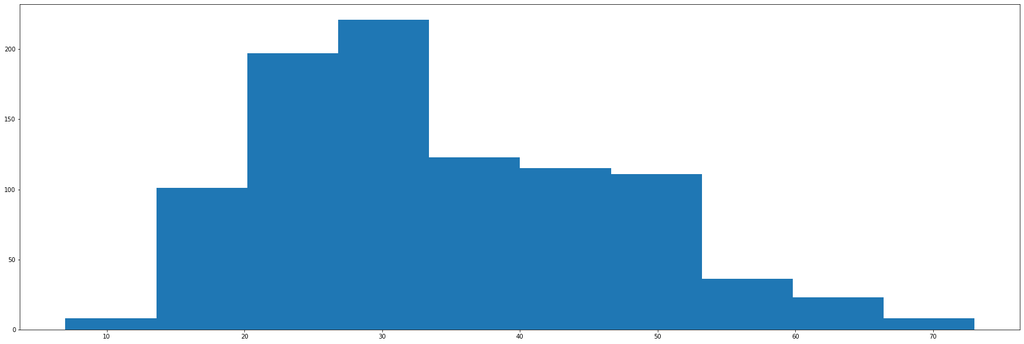

```python
#your answers here
plt.figure(figsize=(30,10))
plt.hist(user['age'], bins=10)
```

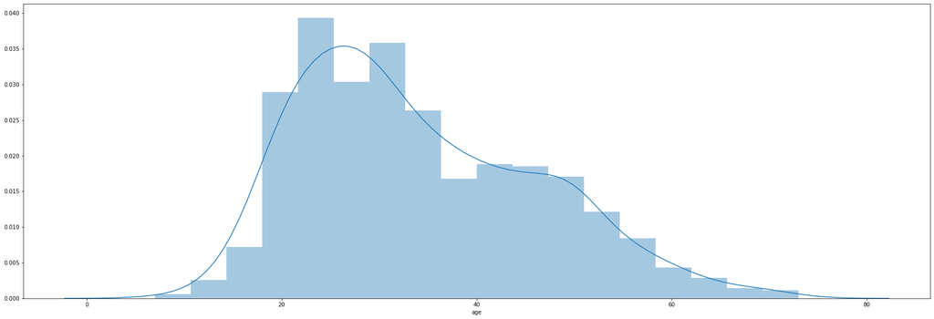

```python
plt.figure(figsize=(30,10))
sns.distplot(user['age'])
```

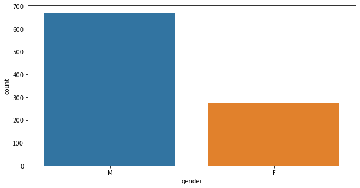

```python
plt.figure(figsize=(10,5))
ax = sns.countplot(x="gender", data=user)
```

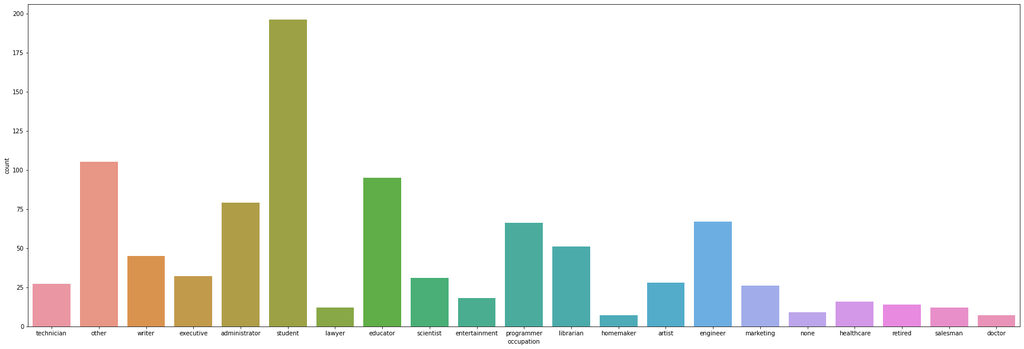

```python
plt.figure(figsize=(30,10))
ax = sns.countplot(x="occupation",data=user)
```

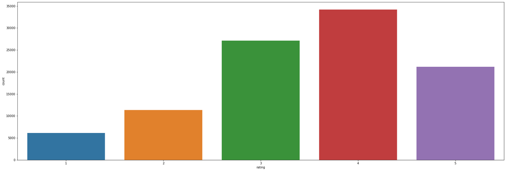

```python
plt.figure(figsize=(30,10))
ax = sns.countplot(x="rating",data=data)
```

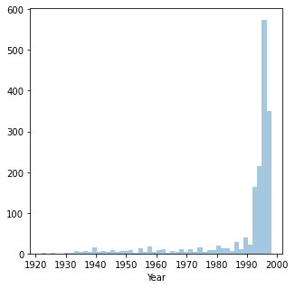

```python
plt.figure(figsize=(5,5))
newtmplist = item[['release date']]
newtmplist['Year'] = pd.DatetimeIndex(newtmplist['release date']).year
ax = sns.distplot(newtmplist['Year'],kde=False)
```

### 8. Visualize how popularity of genres has changed over the years - 10 marks

Note that you need to use the number of releases in a year as a parameter of popularity of a genre

Hint

1: you need to reach to a data frame where the release year is the index and the genre is the column names (one cell shows the number of release in a year in one genre) or vice versa. Once that is achieved, you can either use univariate plots or can use the heatmap to visualise all the changes over the years in one go.

Hint 2: Use groupby on the relevant column and use sum() on the same to find out the nuumber of releases in a year/genre.

[figure not shown]

[figure not shown]

[figure not shown]

[figure not shown]

[figure not shown]

[figure not shown]

[figure not shown]

[figure not shown]

[figure not shown]

[figure not shown]

[figure not shown]

[figure not shown]

[7 more figures not shown]

```python
#Your answer here
tmp = item.copy()
columns = ['movie id','movie title','release date']
tmp.drop(columns, inplace = True,axis=1)

tmplist = item.copy()
tmplist['Year'] = pd.DatetimeIndex(tmplist['release date']).year
tmplist.drop(columns, inplace = True,axis=1)
tmplist.set_index('Year')

for col in tmp.columns:
    ax = tmplist.groupby('Year')[col].sum().sort_values(ascending = False)
    ax= ax.reset_index() # flatten the dataframe

    plt.figure(figsize=(5,5))
    sns.distplot(ax['Year'],axlabel=col,color="y")
```